# R Boot Camp

Chris Woolery

This class is for people who are new to R but also:

- Have intermediate to expert skills in Excel
- Are familiar with basic to intermediate statistics
- Have basic to intermediate skills in some programming language

We will generally be following “R For Data Science” at: https://r4ds.had.co.nz/ which is a much better comprehensive guide than this class.

This class will skip some concepts and accelerate you through this book covering about 50% of what is there. I advise going back and skimming through the things that do not look familiar as they will absolutely come up later in your R journey.

# DAY 3

```r
# Optional memory clear
rm(list=ls())
# Disable Scientific Notation in printing
options(scipen=999)
# Unload All Packages
lapply(names(sessionInfo()$otherPkgs), function(pkgs)
  detach(
    paste0('package:', pkgs),
    character.only = T,
    unload = T,
    force = T
  ))
```

```
## list()
```

```r
library(tidyverse)
```

Let’s load up some publicly available data

```r
GIT_CharTable = "https://raw.githubusercontent.com/RJETAnalytics/TrainingDemo/main/CharTable.RDATA"
download.file(GIT_CharTable,"CharTable.RDATA", method="curl")
CharTable <- readRDS("CharTable.RDATA")

# A custom function to convert a column to a logical variable type while handling
# character values of "NULL"
as.nalogi = function(CharVec) {
  CharVec = if_else(CharVec == "NULL", as.character(NA), CharVec)
  CharVec = as.logical(CharVec)
  return(CharVec)
}

as.nanumeric = function(CharVec) {
  CharVec = if_else(CharVec == "NULL" | is.na(CharVec), as.character("0"), CharVec)
  CharVec = as.numeric(CharVec)
  return(CharVec)
}

# Read a Billboard table where each row is a song and its' rank in the top 100 for every week since the 1950's
demo_BillboardRank <- readr::read_csv('https://raw.githubusercontent.com/rfordatascience/tidytuesday/master/data/2021/2021-09-14/billboard.csv')
# Read a table with song attributes from the Spotify database with an ID that allows us to link them to the Billboard rank table
demo_BillboardFeatures <- readr::read_csv('https://raw.githubusercontent.com/rfordatascience/tidytuesday/master/data/2021/2021-09-14/audio_features.csv')
# Clean up date fields
demo_BillboardRank = demo_BillboardRank %>%
  mutate(week_id = as.Date(week_id, format = "%m/%d/%Y"))

# Clean up character fields for unwanted values
demo_BillboardFeatures = demo_BillboardFeatures %>%
    mutate_if(is.character, function(x) chartr(CharTable$Source, CharTable$Translated, x))

# Read a table where every row is an episode of the cooking competition show Chopped
demo_Chopped <- readr::read_tsv('https://raw.githubusercontent.com/rfordatascience/tidytuesday/master/data/2020/2020-08-25/chopped.tsv')
# Fix data type for date and clean up character fields for unwanted values
demo_Chopped = demo_Chopped %>%
  mutate(air_date = as.Date(air_date, format = "%B %d, %Y")) %>%
  mutate_if(is.character, function(x) chartr(CharTable$Source, CharTable$Translated, x))

# Read a table where every row is an episode of the Scooby Doo cartoon show
demo_ScoobyDoo <- readr::read_csv('https://raw.githubusercontent.com/rfordatascience/tidytuesday/master/data/2021/2021-07-13/scoobydoo.csv')
# Fix data types for numeric and binary fields
demo_ScoobyDoo = demo_ScoobyDoo %>%
  mutate(across(contains(c("imdb",
                           "number_of_snacks", "split_up", "another_mystery",
                           "set_a_trap", "jeepers", "jinkies", "my_glasses",
                           "just_about_wrapped_up", "zoinks", "groovy",
                           "scooby_doo_where_are_you", "rooby_rooby_roo")),
              ~ as.nanumeric(.))) %>%
  mutate(across(contains(c("caught_fred", "caught_daphnie", "caught_velma",
                           "caught_shaggy", "caught_scooby", "captured_fred",
                           "captured_daphnie", "captured_velma", "captured_shaggy",
                           "captured_scooby", "snack_fred", "snack_daphnie",
                           "snack_velma", "snack_shaggy", "snack_scooby",
                           "unmask_fred", "unmask_daphnie", "unmask_velma",
                           "unmask_shaggy", "unmask_scooby")),
              ~ as.nalogi(.))) %>%
  mutate(across(contains(c("trap_work_first", "non_suspect", "arrested")),
              ~ as.nalogi(.)))
```

AGENDA

1. Chopped
1. Explore ratings by year and visualize
2. Reshape data for ratings analysis
3. Explore ratings data
2. In-Class Assignment : using Scooby table
1. Explore ratings by year and visualize
2. Compare ratings by real versus fake Monsters with both a summary bar and box plot
3. Pick some features and explore them
3. Learn to output our data
1. Excel
2. CSV or whatever
3. Billboard
1. Join our rank and features data and filter to relevant columns
2. Explore the data and visualize
3. Build a linear model
4. See if the linear model is predictive using test and train splits

```r
library(lubridate)
```

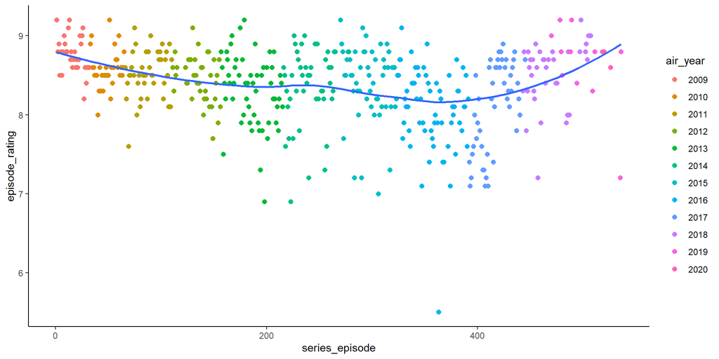

```r
demo_Chopped %>%
  filter(!is.na(episode_rating)) %>%
  mutate(air_year = year(air_date) %>% factor()) %>%
  ggplot(aes(series_episode, episode_rating)) +
    theme_classic() +
    geom_point(aes(color = air_year), size = 2) +
#    geom_line(aes(color = air_year), size = 1)
  geom_smooth(method = "loess", se = FALSE, formula = "y ~ x")
```

```r
# separate_rows is similar to SQL's STRING_SPLIT function
# This creates every combo of ingredient per episode
Chopped_Step1 = demo_Chopped %>%
  separate_rows(appetizer, sep = ",") %>%
  separate_rows(entree, sep = ",") %>%
  separate_rows(dessert, sep = ",") %>%
  mutate(appetizer = str_trim(appetizer),
         entree = str_trim(entree),
         dessert = str_trim(dessert))

# Collapse the ingredients per course into ONE ingredient column
# and remove all possible combinations to just the unique ones with distinct
Chopped_Step2 = bind_rows(
  Chopped_Step1 %>%
    mutate(ingredient = appetizer) %>%
    dplyr::select(series_episode, episode_rating, air_date, judge1, judge2, judge3,
                  contestant1, contestant2, contestant3, contestant4, ingredient),
  Chopped_Step1 %>%
    mutate(ingredient = entree) %>%
    dplyr::select(series_episode, episode_rating, air_date, judge1, judge2, judge3,
                  contestant1, contestant2, contestant3, contestant4, ingredient),
  Chopped_Step1 %>%
    mutate(ingredient = dessert) %>%
    dplyr::select(series_episode, episode_rating, air_date, judge1, judge2, judge3,
                  contestant1, contestant2, contestant3, contestant4, ingredient)) %>%
  distinct() %>%
  arrange(series_episode)
# pivot_longer() would accomplish this in fewer lines of code but its' more opaque

# Collapse Judges into one column
Chopped_Step3 = bind_rows(
  Chopped_Step2 %>%
    mutate(judge = judge1) %>%
    dplyr::select(series_episode, episode_rating, air_date, judge,
                  contestant1, contestant2, contestant3, contestant4, ingredient),
  Chopped_Step2 %>%
    mutate(judge = judge2) %>%
    dplyr::select(series_episode, episode_rating, air_date, judge,
                  contestant1, contestant2, contestant3, contestant4, ingredient),
  Chopped_Step2 %>%
    mutate(judge = judge3) %>%
    dplyr::select(series_episode, episode_rating, air_date, judge,
                  contestant1, contestant2, contestant3, contestant4, ingredient)) %>%
  arrange(series_episode)

# Collapse Contestants into one column
# Now each row is each episode with a row per unique ingredient, judge and contestant
Chopped_Ratings = bind_rows(
  Chopped_Step3 %>%
    mutate(contestant = contestant1) %>%
    dplyr::select(series_episode, episode_rating, air_date,
                  judge, contestant, ingredient),
  Chopped_Step3 %>%
    mutate(contestant = contestant2) %>%
    dplyr::select(series_episode, episode_rating, air_date,
                  judge, contestant, ingredient),
  Chopped_Step3 %>%
    mutate(contestant = contestant3) %>%
    dplyr::select(series_episode, episode_rating, air_date,
                  judge, contestant, ingredient),
  Chopped_Step3 %>%
    mutate(contestant = contestant4) %>%
    dplyr::select(series_episode, episode_rating, air_date,
                  judge, contestant, ingredient)) %>%
  arrange(series_episode)
```

**Which Judges are on Higher Rated Episodes**

Reducing Judges - Filter to certain year or season?

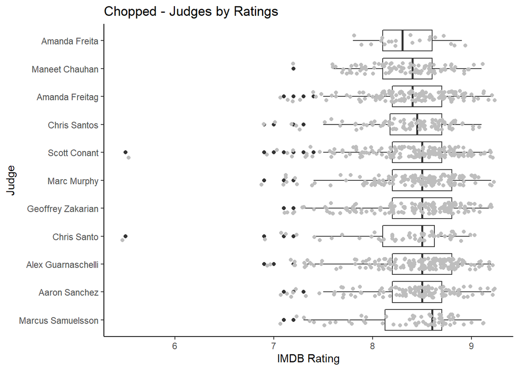

```r
Chopped_Ratings %>%
  filter(!is.na(episode_rating)) %>%
  dplyr::select(series_episode, judge, episode_rating) %>%
  distinct() %>%
  group_by(judge) %>%
  mutate(judge = factor(judge),
         AppearanceCount = n(),
         AvgRating = median(episode_rating)) %>%
  filter(AppearanceCount >= 10) %>%
    ggplot(aes(reorder(judge, desc(AvgRating)), episode_rating)) +
      geom_boxplot() +
      geom_jitter(width = 0.2, color = "grey") +
      coord_flip() +
      theme_classic() +
      labs(title = "Chopped - Judges by Ratings",
           x = "Judge", y = "IMDB Rating")
```

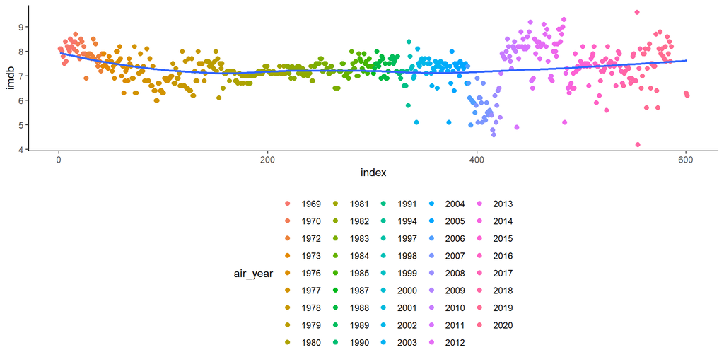

```r
demo_ScoobyDoo %>%
  filter(!is.na(imdb)) %>%
  filter(imdb > 0) %>%
  mutate(air_year = year(date_aired) %>% factor()) %>%
  ggplot(aes(index, imdb)) +
    theme_classic() +
    geom_point(aes(color = air_year), size = 2) +
    geom_smooth(method = "loess", se = FALSE, formula = "y ~ x") +
    theme(legend.position = "bottom")
```

[figure not shown]

```r
demo_ScoobyDoo %>%
  filter(monster_real %in% c("TRUE", "FALSE")) %>%
  mutate(monster_real = factor(monster_real, levels = c("TRUE", "FALSE"))) %>%
  ggplot(aes(monster_real, imdb)) +
    geom_boxplot() +
    coord_flip() +
    theme_classic() +
  labs(title = "Are Real or Fake Monsters More Highly Rated?",
       y = "IMDB Rating", x = "Real Monster?")
```

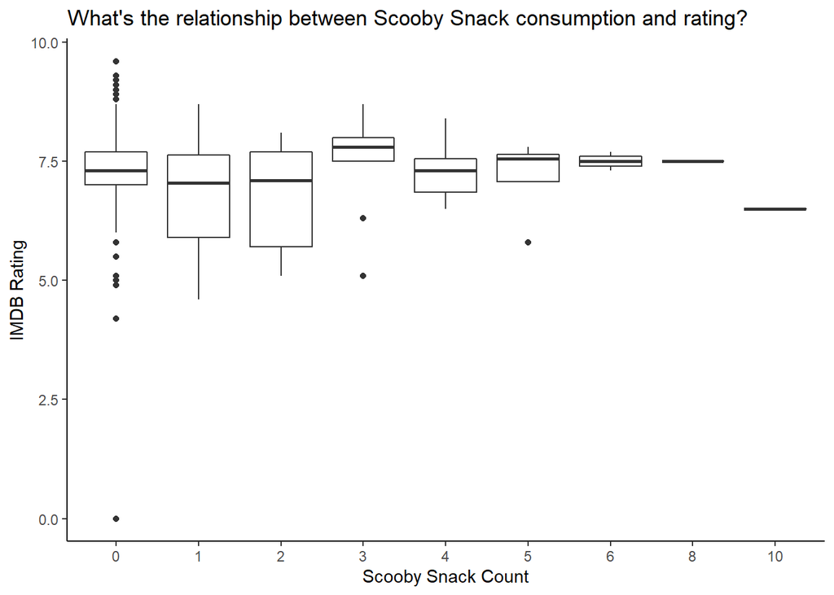

```r
demo_ScoobyDoo %>%
  filter(!is.na(number_of_snacks)) %>%
  ggplot(aes(factor(number_of_snacks), imdb)) +
    geom_boxplot(na.rm = TRUE) +
    theme_classic() +
  labs(title = "What's the relationship between Scooby Snack consumption and rating?",
       y = "IMDB Rating", x = "Scooby Snack Count")
```

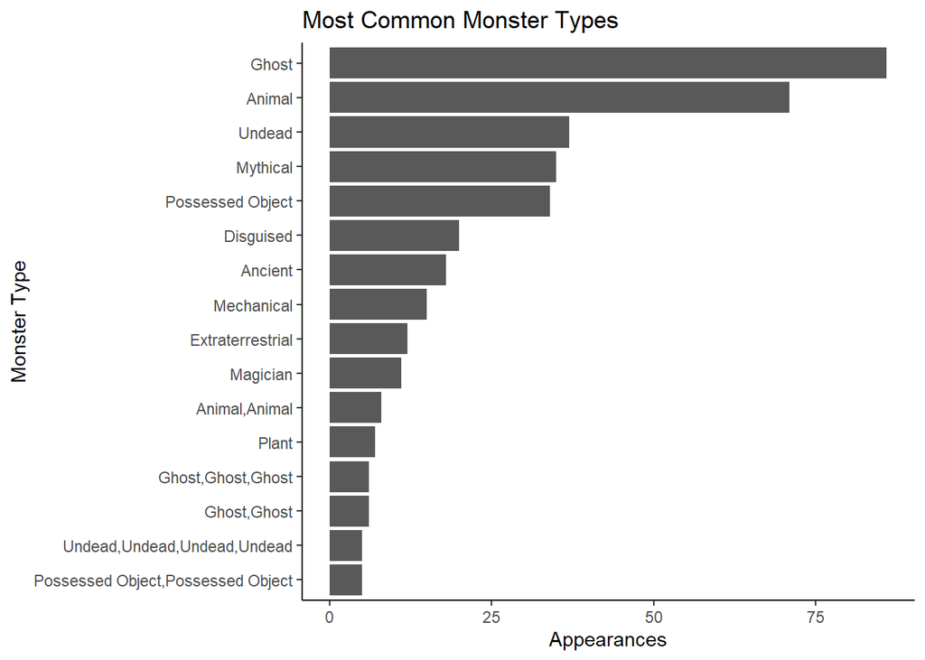

```r
demo_ScoobyDoo %>%
  filter(!is.na(monster_type)) %>%
  filter(!monster_type == "NULL") %>%
  group_by(monster_type) %>%
  summarize(n = n(), .groups = "drop") %>%
  filter(n >= 5) %>%
  ggplot(aes(reorder(monster_type, n), n)) +
    geom_col() +
    theme_classic() +
    coord_flip() +
    labs(title = "Most Common Monster Types",
         x = "Monster Type", y = "Appearances")
```

```r
Billboard_DF = demo_BillboardRank %>%
  dplyr::select(-c(song, performer)) %>%
  inner_join(demo_BillboardFeatures, by = c("song_id" = "song_id")) %>%
  filter(!is.na(spotify_track_popularity))

NumberOnes_DF = Billboard_DF %>%
  filter(week_position == 1) %>%
  group_by(song_id, performer, song, spotify_track_popularity, spotify_genre, mode, danceability, valence) %>%
  summarize(WeeksAt1 = n(), .groups = "drop")

NumberOnes_LM = lm(WeeksAt1 ~ danceability, data = NumberOnes_DF)
```

```r
NumberOnes_LM
```

```
##
## Call:
## lm(formula = WeeksAt1 ~ danceability, data = NumberOnes_DF)
##
## Coefficients:
##  (Intercept)  danceability
##        1.485         2.279
```

```r
# What this means
# WeeksAt1 = 2.279 X danceability + 1.485
```

```r
summary(NumberOnes_LM)
```

```
##
## Call:
## lm(formula = WeeksAt1 ~ danceability, data = NumberOnes_DF)
##
## Residuals:
##    Min     1Q Median     3Q    Max
## -2.713 -1.722 -0.815  0.815 34.515
##
## Coefficients:
##              Estimate Std. Error t value  Pr(>|t|)
## (Intercept)    1.4847     0.3583   4.144 0.0000370 ***
## danceability   2.2787     0.5542   4.111 0.0000425 ***
## ---
## Signif. codes:  0 '***' 0.001 '**' 0.01 '*' 0.05 '.' 0.1 ' ' 1
##
## Residual standard error: 2.666 on 1007 degrees of freedom
## Multiple R-squared:  0.01651,    Adjusted R-squared:  0.01553
## F-statistic:  16.9 on 1 and 1007 DF,  p-value: 0.00004254
```